# To Sink a Warship

Analyzing the Losses of the Imperial Japanese Navy

Matthew J. DiRisio (George Mason University)  
2019-05-13

The war in the Pacific during World War II (WWII) witnessed the advent of the aircraft carrier as the preeminent strike weapon, the maturation of United States Navy (USN) submarine forces, and the decline of traditional all-gun surface warships. All of these methods, and few others, combined to pummel the Imperial Japanese Navy (IJN) into submission by 1945. Traditionally, many WWII naval historians and scholars such as David Jones, Jim Christley, and Clay Blair have pointed to the USN submarine fleet as being a deciding factor. This approach has some merit when it comes to dissecting the losses of the Japanese maritime merchant fleet. However, when it comes to the IJN proper, the research in this paper seeks to lay out a case that it was actually the USN carrier fleet’s aircraft that did the true heavy lifting during the war. Although USN submarines sank more Japanese merchant ships, they were not as effective against the capital ships, such as aircraft carriers and battleships, of the IJN. This paper utilizes the extensive records of the Joint Army Navy Assessment Committee (JANAC) as a historical dataset to take a deeper look into IJN warship losses from 1941-1945, and sort through their causes of losses as well the method by which they were sunk.[^1] The JANAC was an inter-service United States Department of Defense program set up in 1943 to evaluate and measure Japanese naval and commercial ship losses caused by Allied forces during WWII. The cataloging of all Japanese Naval losses concluded in 1947 and established dates, tonnage, name, cause, sinking country, and sinking agents for every loss. This represents a significant source of previously untapped data, which correctly formatted, can be ran through R to gain a better understanding of change over time.[^2]

A more detailed look at the data yielded some interesting results. The data was pulled directly from the Naval History and Heritage Command Website. Without becoming too ensnared in the details, this was a relatively tedious process of copying and pasting the data into an Excel sheet, cleaning it, converting it into a Comma Separated Value (CSV) sheet, running it through Open Refine, and finally uploading it into R. It consists of 681 rows, each containing one IJN warship sunk during WWII and the relevant info concerning it. Although comprehensive, the data is thoroughly one-dimensional. It is simply a list of sunken naval warships, with some information on the specifics of sinking cause and what agent and country did the sinking. What the data does not do is answer the “why” or making any attempt to break down changing trends over time. The computational methods used by this article help to bridge the gap between the raw data of the JANAC and the actual operational processes which caused these outcomes. With a fair amount of refinement and cleaning, the data is more than sufficient to go some ways towards accomplishing this.

One of the first things that jumps out when looking at the data is the sheet number of losses suffered by the IJN. Within the context of the losses, the losses of Japanese escort warships are particularly alarming, with nearly half (338 of the total 681 warships sunk) belonging to this type of warship. [^3] This will be discussed in greater context later in this paper. To put it bluntly, if Japanese capital ships were vulnerable to aircraft, surely their lightest and least well defended warships would suffer grievously as well.

| id | date | name | type | tonnage | lat | lon | flag | agent |
| --- | --- | --- | --- | --- | --- | --- | --- | --- |
| 1 | 1941-12-10 | I 170 | submarine | 1785 | 23-45N | 155-35W | united_states | navy_carrier_based_aircraft |
| 2 | 1941-12-10 | MINESWEEPER NO 10 | minesweeper | 630 | 17-32N | 120-22E | united_states | land_based_aircraft |
| 3 | 1941-12-10 | MINESWEEPER NO 19 | minesweeper | 492 | 18-22N | 121-38E | united_states | land_based_aircraft |
| 4 | 1941-12-11 | HAYATE | escort | 1270 | 19-16N | 166-37E | united_states | shore_battery |
| 5 | 1941-12-11 | KISARAGI | escort | 1500 | 19-16N | 166-37E | united_states | shore_battery |
| 6 | 1941-12-17 | RO 66 | submarine | 988 | 19-25N | 166-30E | japan | marine_casualty |
| 7 | 1941-12-18 | SHINONOME | escort | 1950 | 4-24N | 114-00E | netherlands | mine |
| 8 | 1941-12-22 | PATROL BOAT NO 32 | escort | 750 | 19-17N | 166-35E | japan | marine_casualty |
| 9 | 1941-12-22 | PATROL BOAT NO 33 | escort | 750 | 19-17N | 166-35E | japan | marine_casualty |
| 10 | 1941-12-24 | SAGIRI | escort | 1950 | 1-34N | 110-21E | netherlands | submarine |

[output cut: 671 more lines]

Table 1. This table shows the data utilized for this project. It is based upon that in [*Japanese Naval and Merchant Shipping Losses During World War II by All Causes*](https://www.history.navy.mil/research/library/online-reading-room/title-list-alphabetically/j/japanese-naval-merchant-shipping-losses-wwii.html) Some simplification of Japanese ship types was required. These have been boiled down to “Capital Ship”, “Submarine”, “Escort”, “Minesweeper”, or “Miscellaneous Auxiliary.” To reduce mistakes and coding errors, every ship sinking is limited to one agent, either “Navy Carrier Based Aircraft”, “Land Based Aircraft”, Surface Craft”, “Shore Battery”, “Mine”, or “Marine Casualty.” This required some level of research and decision making as to the agent that caused the most catastrophic damage if multiple agents are cited in the JANAC. The below graph has been broken down into the three greatest sinking agents: Navy Carrier Based Aircraft, Submarines, and Surface Craft. The author assumes sole responsbility for these decisions.

### The Ascendance of Aircraft Carriers

The practicality of aircraft carriers was validated early in the war, when the Japanese decimated the United States Pacific fleet at Pearl Harbor on December 7, 1941. Most crucially during this attack, the Japanese sank no US aircraft carriers. The first large spike on the graph below occurs in 1942, and this is the Battle of Midway in June of 1942. During this battle, four Japanese aircraft carriers [^4] and a heavy cruiser [^5] were sunk. All of these ships were sunk by Navy Carrier Based Aircraft. If the reader observes the spikes, it is easy to track the major events of the Pacific War. The other three spikes are the Battle of Leyte Gulf, the sinking of the Yamato, a truly massive ship that weighed in 70,000 tons by itself, and the Kure Harbor Naval Air Raid in July, 1945. In comparison, Submarines do not have the large spikes that Navy Carrier Based Aircraft do but possess a relatively consistent flow throughout the war judging by the graph. Lastly, Surface Craft [^6] only manage one small spike, the First and Second Naval Battles of Guadalcanal in late 1942, and one large spike which is the Battle of Leyte Gulf in late 1944. By 1945 the United States Navy contained 32 aircraft carriers and over 1,700 carrier based aircraft, in comparison to just three operational Japanese aircraft carriers and fewer than 200 carrier-based aircraft.[^7] For all the effort put into building the USN surface fleet, it played a largely ancillary role during the war, mainly functioning as a shore bombardment force during the island-hopping campaign, and as escorting anti-aircraft capability for the aircraft carriers. [^8]

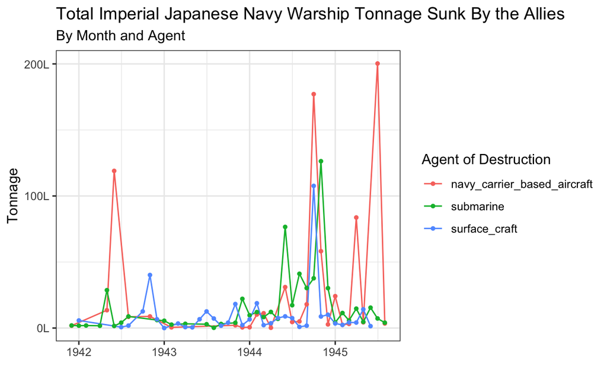

Figure 1: This chart depicts the monthly Japanese warship tonnage sunk, and breaks it down by each individual sinking agent. For the purposes of this paper, it has been broken down into the three largest sinking agents. There are others, such as Shore Batteries, that sank so few ships (four ships in the case of Shore Batteries) they barely figure into the data and therefore were not included for this depiction.

### A Shrinking World

As the war progressed, the Japanese sea lanes became constricted. It is outside the scope of this paper, but the Dutch East Indies (present-day Indonesia) provided the bulk of Japanese fuel. As these were cut off, Japanese vessels could not afford to range as far as they did previously. If the reader looks at the interactive map below, they can see that the preponderance of Japanese warship losses occurred in what are known as littoral waters. The littoral zone extends 25 nautical miles from the coastline. By 1945, over 95% of Japanese losses occurred within the littoral zones of their territories. With the exception of the *Yamato*, all of the Japanese capital ships sunk during 1945 were sunk within littoral waters. All of these ships would be sunk by US Navy carrier-based aircraft. The closure of Japanese shipping lanes caused fuel shortages which saw more and more of the Japanese fleet tied up at anchor. At this point, bereft of the ability to maneuver, they were sitting ducks for strikes by aircraft. [^9]

[interactive chart not shown]

### Why So Many Green Circles: Explaining the Death of the Kaibōkan

What is not included in this paper is the decline of the Japanese ship building industry. As the war went on the Imperial Japanese Navy was forced to design and build simpler, more easily mass-produced ships. The Japanese called these ships *Kaibōkan*, or “ocean defense ships,” a name used to denote a multi-purpose vessel.[^10] These ships were much smaller and less heavily armed than their predecessors. They sufficed for anti-submarine work, but little else. However, by 1945 these ships formed a major part of Japanese naval strength due to lack of new warships and fuel shortages. They were expendable and saw heavy losses in the last year of the war.[^11]

The chart below depicts Japanese warship losses during the last year of the war in 1945. Japanese escort warships made up nearly 71% of all losses that year. Their smaller size and tonnage meant that they consumed less of the dwindling fuel reserves that the Imperial Japanese Navy possessed. At the same time, their diminished size led to their general inability to defend themselves. The *Kaibōkan* were certainly expedient vessels to produce, but that also led to the fatal flaws of their design. The Japanese sailors who put to sea in these warships (with warship being a very loose term to describe these compared to their predecessors) were facing long odds at achieving any success. Their use in combat is a symbol of the desperation experienced by the Japanese Navy during the final year of the war.

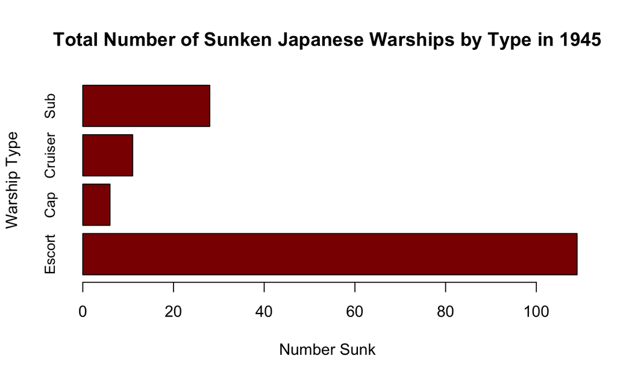

Figure 3: This bar graph depicts the four types of Imperial Japanese Navy warships that suffered the greatest losses in 1945. The focus of this graph is total number sunk rather than tonnage of the ships.

### Endgame: What Happens When the Fuel Runs Out

By early 1945, almost all capital ships of the Imperial Japanese Navy had been deactivated and were laid up in harbor. Formidable battleships, and even aircraft carriers, that cost enormous sums to build before the war with the United Sates were mere cold steel tied up to the dock due to a lack of fuel to power them. When the US Navy and Marine Corps invaded Iwo Jima in February of 1945, the Japanese conceded the sea lanes and littoral waters without a fight. The situation dictated that only the smallest and most economical ships to use could be utilized in the defense of the Japanese home islands. This meant that the Japanese escort warships would bear the brunt of the US Navy’s fury as the war drew closer to an end. The Japanese Navy’s decision-making methods could not manage to defend against American attacks on all fronts any longer. Instead, it required the majority of its meager resources just to preserve its shrinking levels of oil reserves and maintain basic supply transfers between the home islands.

This is why the vast majority of Japanese ships sunk during 1945 were escort vessels. It is also why Navy Carrier Based Aircraft were the only agent of destruction sinking any of the larger Japanese vessels. The graph below shows that with the exception of three cruisers, all of the cruiser losses for 1945 were inflicted by aircraft. As for the Japanese capital ships, such as battleships and aircraft carriers, there would be no more sorties. There was of course one exception to this. In April 1945, the Japanese battleship *Yamato* along with nine other Japanese warships, embarked from Japan on a deliberate suicide attack upon Allied forces engaged in the Battle of Okinawa. The *Yamato* was the largest battleship ever built, weighing in at nearly 70,000 tons. In a few hours, hundreds of US Navy Carrier Based Aircraft sank the *Yamato* and six of her nine escorts. The Japanese lost over 4,000 men on the sunken warships, the Americans lost 10 aircraft and 12 men. This was the only Japanese capital ship sunk on the open ocean in 1945. The other five were all sunk in harbor while tied up to the dock for want of fuel. [^12]

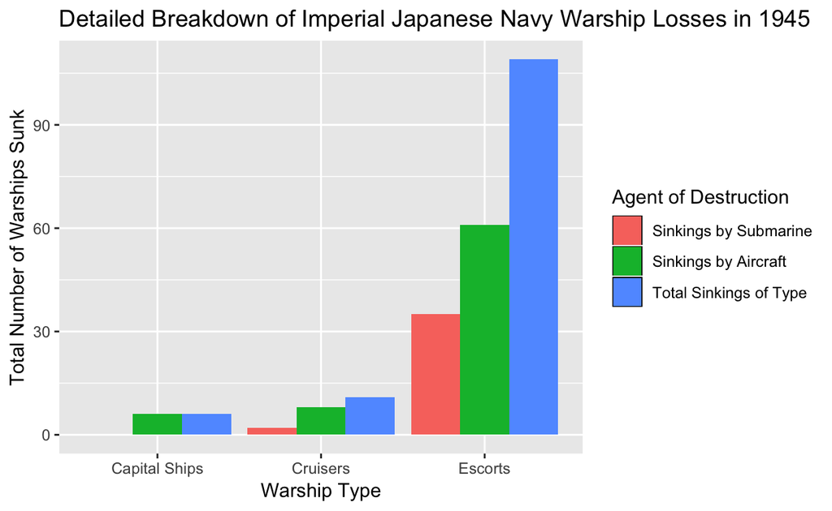

### Conclusion

The Second World War remains perhaps the most studied period of history for military historians. Innumerable histories of the War in the Pacific have been written, with many of these even featuring perspectives and primary sources from the Japanese side of the conflict. [^13] Previous authors of the conflict have focused on the contributions of the US Navy’s submarine fleet to help explain victory in the Pacific. While not insignificant, based upon a computational approach it is clearly evident that by 1945 the US Navy carrier-based aircraft reigned supreme in the Pacific. Some of the reasons for this, such as the Imperial Japanese Navy’s lack of fuel by this point in the war, were largely out of the control of US Navy submariners. Regardless, the carrier-based aircraft could venture where submarines and surface craft could not, directly above the harbors were the IJN’s fuel-starved fleet attempted to lay hidden. This computational approach has barely scratched the surface of the naval warfare that occurred in the Pacific Theater during World War II. Admittedly, this paper paints the war in rather broad brushstrokes. There is vast potential for future research to more thoroughly examine specific events and battles to yield new perspectives on previously accepted history.

[^1]: The Joint Army-Navy Assessment Committee, NAVEXOS P 468, *Japanese Naval and Merchant Shipping Losses During World War II by All Causes*, February, 1947 https://www.history.navy.mil/research/library/online-reading-room/title-list-alphabetically/j/japanese-naval-merchant-shipping-losses-wwii.html
[^2]: For examples of typical USN histories highlighting submarines see Clay Blair, *Silent Victory: The U.S. Submarine War Against Japan*. (Annapolis: Naval Institute Press, 2001), David Jones, *U.S. Subs Down Under. Brisbane, 1942–1945* (Annapolis: Naval Institute Press, 2005), and Jim Christley, *US Submarines 1941–45* (Oxford: Ospery Publishing, 2006)
[^3]: For the purposes of this study, I grouped together several classes of escorts in the JANAC, such as destroyers, frigates, patrol boats, torpedo boats, and submarine chasers.
[^4]: If the reader examines the data, all the aircraft carriers are lumped together with the battleships as capital ships, for the purposes of simplicity and ease of data manipulation.
[^5]: In a similar manner, all cruisers in the data, whether heavy or light, are simply referred to as “cruisers”.
[^6]: Surface craft includes everything that sinks enemy ships with guns and/or torpedoes, from PT boats to battleships.
[^7]: Peter Hore, *The World Encyclopedia of Battleships* (London: Hermes House, 2005)
[^8]: For more on the debate between aircraft carriers and all-gun surface units, see John B. Lundstrom, *The First Team: Pacific Naval Air Combat from Pearl Harbor to Midway* (Annapolis: Naval Institute Press, 1984).
[^9]: For more on the constriction of Japanese supply movement, see Mark Parillo, *The Japanese Merchant Marine in World War II* (Annapolis: Naval Institute Press, 1993)
[^10]: (Kai = sea, ocean, Bō = defense, Kan = ship
[^11]: For more information on *Kaibōkan* see Mark Stille, *Imperial Japanese Navy Antisubmarine Escorts* (Oxford: Osprey, 2017),
[^12]: For more on Operation Ten-Go and the *Yamato* see Janusz Skulski, *The Battleship Yamato* (Annapolis: Naval Institute Press, 1989)
[^13]: For a comprehensive primary source written from the Japanese perspective, see Capt. Tameichi Hara, *Japanese Destroyer Captain: Pearl Harbor, Guadalcanal, Midway- The Great Naval Battles as Seen Through Japanese Eyes* (Annapolis: The Naval Institute Press, 2006)